# What Do You Know About Starbucks Coffee Company?

by Aldi Irianto

08 October 2022

## Brief History of Starbucks

‘Behind every cup of coffee is a story’. The story of Starbucks begins in 1971 along opened its first store of Seattle’s historic Pike Place Market. This first store where Starbucks offering fresh-roasted coffee beans, tea, and spices from around the world for their customers.

Howard Schultz, a young New Yorker joining the company in 1982. Howard have another experienced at Italy’s coffehouses, and he planed to bring the warmth and artistry of its coffee culture to Starbucks in Seattle.

By 1987, Starbucks officially used green aprons and embarked next chapter as a coffehouse.

### Starbucks Around The World

Initially, Starbucks were gaining popularity around the world.

```r
#Data Input and Checking the Data
starbucks = read.csv(file = "Hands-On/Starbucks/starbucks-location.csv")
```

```r
head(starbucks)
```

[output not shown]

[output cut: 34 more lines]

```r
#Checking columns name
names(starbucks)
```

```
##  [1] "X"                      "storeNumber"            "countryCode"
##  [4] "ownershipTypeCode"      "schedule"               "slug"
##  [7] "latitude"               "longitude"              "streetAddressLine1"
## [10] "streetAddressLine2"     "streetAddressLine3"     "city"
## [13] "countrySubdivisionCode" "postalCode"             "currentTimeOffset"
## [16] "windowsTimeZoneId"      "olsonTimeZoneId"
```

```r
#Inspecting Data & Data Cleaning, eliminate the unrated data (columns number 5,6,14,15,16,17

starbucks$countryCode = as.factor(starbucks$countryCode)
starbucks$countrySubdivisionCode = as.factor(starbucks$countrySubdivisionCode)
starbucks$city = as.factor(starbucks$city)

starbucks <- starbucks[,-c(5,6,14,15,16,17)]
str(starbucks)
```

```
## 'data.frame':    28289 obs. of  11 variables:
##  $ X                     : int  0 1 2 3 4 5 6 7 8 9 ...
##  $ storeNumber           : chr  "34638-85784" "32141-267986" "15035-155445" "49646-268445" ...
##  $ countryCode           : Factor w/ 49 levels "AE","AR","AT",..: 20 20 20 20 20 20 20 20 20 20 ...
##  $ ownershipTypeCode     : chr  "LS" "LS" "LS" "LS" ...
##  $ latitude              : num  22.3 22.3 22.3 22.3 22.3 ...
##  $ longitude             : num  114 114 114 114 114 ...
##  $ streetAddressLine1    : chr  "Level 2, Plaza Hollywood, Diamond Hill," "Shop No. G3B, Ground Floor, Wong Tai Sin" "Shop No. G01, Ground Floor, Mikiki 638" "九龍九龍城廣場 地下低層LG10舖" ...
##  $ streetAddressLine2    : chr  "Kowloon" "Shopping Centre, Wong Tai Sin, Kowloon" "Prince Edward Road East," "" ...
##  $ streetAddressLine3    : chr  "" "" "" "" ...
##  $ city                  : Factor w/ 5457 levels ", Klongluang, Pathumthani",..: 2057 2057 2471 5457 2057 2473 2471 2057 2472 2057 ...
##  $ countrySubdivisionCode: Factor w/ 268 levels "00","01","02",..: 66 66 66 66 66 66 66 66 66 66 ...
```

```r
#View null data

colSums(is.na(starbucks))
```

```
##                      X            storeNumber            countryCode
##                      0                      0                      0
##      ownershipTypeCode               latitude              longitude
##                      0                      0                      0
##     streetAddressLine1     streetAddressLine2     streetAddressLine3
##                      1                      0                      0
##                   city countrySubdivisionCode
##                      1                      0
```

As we see above, we have very few missing data. So we can move to next steps.

```r
#Checking variabel CountryCode
levels(starbucks$countryCode)
```

```
##  [1] "AE" "AR" "AT" "AW" "BE" "BG" "BH" "BN" "BS" "CA" "CL" "CN" "CZ" "DE" "ES"
## [16] "FR" "GB" "GR" "GT" "HK" "HU" "ID" "IE" "JO" "JP" "KR" "KW" "LB" "MO" "MX"
## [31] "MY" "NL" "NZ" "OM" "PE" "PH" "PL" "PT" "QA" "RO" "RU" "SA" "SG" "SK" "SV"
## [46] "TH" "TR" "TW" "US"
```

```r
#install library countrycode
library(countrycode)
```

```r
#Checking Country Name by its ISO-II
country_name = countrycode(c("AE", "AR", "AT", "AW", "BE", "BG", "BH", "BN", "BS", "CA", "CL", "CN", "CZ", "DE", "ES", "FR", "GB", "GR", "GT", "HK", "HU", "ID", "IE", "JO", "JP", "KR", "KW", "LB", "MO", "MX", "MY", "NL", "NZ", "OM", "PE", "PH", "PL", "PT", "QA", "RO", "RU", "SA", "SG", "SK", "SV", "TH", "TR", "TW", "US"), origin = 'iso2c', destination = 'country.name')

country_name
```

```
##  [1] "United Arab Emirates" "Argentina"            "Austria"
##  [4] "Aruba"                "Belgium"              "Bulgaria"
##  [7] "Bahrain"              "Brunei"               "Bahamas"
## [10] "Canada"               "Chile"                "China"
## [13] "Czechia"              "Germany"              "Spain"
## [16] "France"               "United Kingdom"       "Greece"
## [19] "Guatemala"            "Hong Kong SAR China"  "Hungary"
## [22] "Indonesia"            "Ireland"              "Jordan"
## [25] "Japan"                "South Korea"          "Kuwait"
## [28] "Lebanon"              "Macao SAR China"      "Mexico"
## [31] "Malaysia"             "Netherlands"          "New Zealand"
## [34] "Oman"                 "Peru"                 "Philippines"
## [37] "Poland"               "Portugal"             "Qatar"
## [40] "Romania"              "Russia"               "Saudi Arabia"
## [43] "Singapore"            "Slovakia"             "El Salvador"
## [46] "Thailand"             "Turkey"               "Taiwan"
## [49] "United States"
```

```r
#Creating new variable Country Name
starbucks$countryName[starbucks$countryCode=='AE'] <- "United Arab Emirates"
starbucks$countryName[starbucks$countryCode=='AR'] <- "Argentina"
starbucks$countryName[starbucks$countryCode=='AT'] <- "Austria"
starbucks$countryName[starbucks$countryCode=='AW'] <- "Aruba"
starbucks$countryName[starbucks$countryCode=='BE'] <- "Belgium"
starbucks$countryName[starbucks$countryCode=='BG'] <- "Bulgaria"
starbucks$countryName[starbucks$countryCode=='BH'] <- "Bahrain"
starbucks$countryName[starbucks$countryCode=='BN'] <- "Brunei"
starbucks$countryName[starbucks$countryCode=='BS'] <- "Bahamas"
starbucks$countryName[starbucks$countryCode=='CA'] <- "Canada"
starbucks$countryName[starbucks$countryCode=='CL'] <- "Chile"
starbucks$countryName[starbucks$countryCode=='CN'] <- "China"
starbucks$countryName[starbucks$countryCode=='CZ'] <- "Czechia"
starbucks$countryName[starbucks$countryCode=='DE'] <- "Germany"
starbucks$countryName[starbucks$countryCode=='ES'] <- "Spain"
starbucks$countryName[starbucks$countryCode=='FR'] <- "France"
starbucks$countryName[starbucks$countryCode=='GB'] <- "United Kingdom"
starbucks$countryName[starbucks$countryCode=='GR'] <- "Greece"
starbucks$countryName[starbucks$countryCode=='GT'] <- "Guatemala"
starbucks$countryName[starbucks$countryCode=='HK'] <- "Hong Kong SAR China"
starbucks$countryName[starbucks$countryCode=='HU'] <- "Hungary"
starbucks$countryName[starbucks$countryCode=='ID'] <- "Indonesia"
starbucks$countryName[starbucks$countryCode=='IE'] <- "Ireland"
starbucks$countryName[starbucks$countryCode=='JO'] <- "Jordan"
starbucks$countryName[starbucks$countryCode=='JP'] <- "Japan"
starbucks$countryName[starbucks$countryCode=='KR'] <- "South Korea"
starbucks$countryName[starbucks$countryCode=='KW'] <- "Kuwait"
starbucks$countryName[starbucks$countryCode=='LB'] <- "Lebanon"
starbucks$countryName[starbucks$countryCode=='MO'] <- "Macao SAR China"
starbucks$countryName[starbucks$countryCode=='MX'] <- "Mexico"
starbucks$countryName[starbucks$countryCode=='MY'] <- "Malaysia"
starbucks$countryName[starbucks$countryCode=='NL'] <- "Netherlands"
starbucks$countryName[starbucks$countryCode=='NZ'] <- "New Zealand"
starbucks$countryName[starbucks$countryCode=='OM'] <- "Oman"
starbucks$countryName[starbucks$countryCode=='PE'] <- "Peru"
starbucks$countryName[starbucks$countryCode=='PH'] <- "Philippines"
starbucks$countryName[starbucks$countryCode=='PL'] <- "Poland"
starbucks$countryName[starbucks$countryCode=='PT'] <- "Portugal"
starbucks$countryName[starbucks$countryCode=='QA'] <- "Qatar"
starbucks$countryName[starbucks$countryCode=='RO'] <- "Romania"
starbucks$countryName[starbucks$countryCode=='RU'] <- "Russia"
starbucks$countryName[starbucks$countryCode=='SA'] <- "Saudi Arabia"
starbucks$countryName[starbucks$countryCode=='SG'] <- "Singapore"
starbucks$countryName[starbucks$countryCode=='SK'] <- "Slovakia"
starbucks$countryName[starbucks$countryCode=='SV'] <- "El Salvador"
starbucks$countryName[starbucks$countryCode=='TH'] <- "Thailand"
starbucks$countryName[starbucks$countryCode=='TR'] <- "Turkey"
starbucks$countryName[starbucks$countryCode=='TW'] <- "Taiwan"
starbucks$countryName[starbucks$countryCode=='US'] <- "United States"
```

```r
starbucks$countryName <- as.factor(starbucks$countryName)
levels(starbucks$countryName)
```

```
##  [1] "Argentina"            "Aruba"                "Austria"
##  [4] "Bahamas"              "Bahrain"              "Belgium"
##  [7] "Brunei"               "Bulgaria"             "Canada"
## [10] "Chile"                "China"                "Czechia"
## [13] "El Salvador"          "France"               "Germany"
## [16] "Greece"               "Guatemala"            "Hong Kong SAR China"
## [19] "Hungary"              "Indonesia"            "Ireland"
## [22] "Japan"                "Jordan"               "Kuwait"
## [25] "Lebanon"              "Macao SAR China"      "Malaysia"
## [28] "Mexico"               "Netherlands"          "New Zealand"
## [31] "Oman"                 "Peru"                 "Philippines"
## [34] "Poland"               "Portugal"             "Qatar"
## [37] "Romania"              "Russia"               "Saudi Arabia"
## [40] "Singapore"            "Slovakia"             "South Korea"
## [43] "Spain"                "Taiwan"               "Thailand"
## [46] "Turkey"               "United Arab Emirates" "United Kingdom"
## [49] "United States"
```

```r
#Creating new variable sub-continent
starbucks$sub_continent[starbucks$countryName == "United Arab Emirates"] <- "Middle East"
starbucks$sub_continent[starbucks$countryName == "Argentina"]<-"South America"
starbucks$sub_continent[starbucks$countryName=="Austria"]<-"Central Europe"
starbucks$sub_continent[starbucks$countryName=="Aruba"]<-"South America"
starbucks$sub_continent[starbucks$countryName=="Bahrain"]<-"Middle East"
starbucks$sub_continent[starbucks$countryName=="Brunei"]<-"Southeast Asia"
starbucks$sub_continent[starbucks$countryName=="Bahamas"]<-"North America"
starbucks$sub_continent[starbucks$countryName=="Canada"]<-"North America"
starbucks$sub_continent[starbucks$countryName=="Chile"]<-"South America"
starbucks$sub_continent[starbucks$countryName=="China"]<-"East Asia"
starbucks$sub_continent[starbucks$countryName=="Czechia"]<-"Central Europe"
starbucks$sub_continent[starbucks$countryName=="Germany"]<-"Western Europe"
starbucks$sub_continent[starbucks$countryName=="Spain"]<-"South-western Europe"
starbucks$sub_continent[starbucks$countryName=="France"]<-"Western Europe"
starbucks$sub_continent[starbucks$countryName=="United Kingdom"]<-"West Europe"
starbucks$sub_continent[starbucks$countryName=="Greece"]<-"Southeast Europe"
starbucks$sub_continent[starbucks$countryName=="Guatemala"]<-"Central America"
starbucks$sub_continent[starbucks$countryName=="Hong Kong SAR China"]<-"East Asia"
starbucks$sub_continent[starbucks$countryName=="Hungary"]<-"Central Europe"
starbucks$sub_continent[starbucks$countryName=="Indonesia"]<-"Southeast Asia"
starbucks$sub_continent[starbucks$countryName=="Ireland"]<-"North-western Europe"
starbucks$sub_continent[starbucks$countryName=="Jordan"]<-"Middle East"
starbucks$sub_continent[starbucks$countryName=="Japan"]<-"East Asia"
starbucks$sub_continent[starbucks$countryName=="South Korea"]<-"East Asia"
starbucks$sub_continent[starbucks$countryName=="Kuwait"]<-"Middle East"
starbucks$sub_continent[starbucks$countryName=="Lebanon"]<-"Middle East"
starbucks$sub_continent[starbucks$countryName=="Macao SAR China"]<-"East Asia"
starbucks$sub_continent[starbucks$countryName=="Mexico"]<-"North America"
starbucks$sub_continent[starbucks$countryName=="Malaysia"]<-"Southeast Asia"
starbucks$sub_continent[starbucks$countryName=="Netherlands"]<-"West Europe"
starbucks$sub_continent[starbucks$countryName=="New Zealand"]<-"Oceania"
starbucks$sub_continent[starbucks$countryName=="Oman"]<-"Middle East"
starbucks$sub_continent[starbucks$countryName=="Peru"]<-"South America"
starbucks$sub_continent[starbucks$countryName=="Philippines"]<-"Southeast Asia"
starbucks$sub_continent[starbucks$countryName=="Poland"]<-"Central Europe"
starbucks$sub_continent[starbucks$countryName=="Portugal"]<-"South-western Europe"
starbucks$sub_continent[starbucks$countryName=="Qatar"]<-"Western Asia"
starbucks$sub_continent[starbucks$countryName=="Romania"]<-"South-eastern Europe"
starbucks$sub_continent[starbucks$countryName=="Russia"]<-"Eastern Europe & Northern Asia"
starbucks$sub_continent[starbucks$countryName=="Saudi Arabia"]<-"Middle East"
starbucks$sub_continent[starbucks$countryName=="Singapore"]<-"Southeast Asia"
starbucks$sub_continent[starbucks$countryName=="Slovakia"]<-"Central Europe"
starbucks$sub_continent[starbucks$countryName=="El Salvador"]<-"Central America"
starbucks$sub_continent[starbucks$countryName=="Thailand"]<-"Southeast Asia"
starbucks$sub_continent[starbucks$countryName=="Turkey"]<-"Middle East"
starbucks$sub_continent[starbucks$countryName=="Taiwan"]<-"East Asia"
starbucks$sub_continent[starbucks$countryName=="United States"]<-"North America"
```

```r
starbucks$sub_continent <- as.factor(starbucks$sub_continent)
levels(starbucks$sub_continent)
```

```
##  [1] "Central America"                "Central Europe"
##  [3] "East Asia"                      "Eastern Europe & Northern Asia"
##  [5] "Middle East"                    "North-western Europe"
##  [7] "North America"                  "Oceania"
##  [9] "South-eastern Europe"           "South-western Europe"
## [11] "South America"                  "Southeast Asia"
## [13] "Southeast Europe"               "West Europe"
## [15] "Western Asia"                   "Western Europe"
```

```r
#Creating new variable continent
starbucks$continent[starbucks$sub_continent=="Central America"] <- "America"
starbucks$continent[starbucks$sub_continent=="Central Europe"] <- "Europe"
starbucks$continent[starbucks$sub_continent=="East Asia"] <- "Asia"
starbucks$continent[starbucks$sub_continent=="Eastern Europe & Northern Asia"] <- "Asia"
starbucks$continent[starbucks$sub_continent=="Middle East"] <- "Asia"
starbucks$continent[starbucks$sub_continent=="North-western Europe"] <- "Europe"
starbucks$continent[starbucks$sub_continent=="North America"] <- "America"
starbucks$continent[starbucks$sub_continent=="Oceania"] <- "Australia/Oceania"
starbucks$continent[starbucks$sub_continent=="South-eastern Europe"] <- "Europe"
starbucks$continent[starbucks$sub_continent=="South-western Europe"] <- "Europe"
starbucks$continent[starbucks$sub_continent=="South America"] <- "America"
starbucks$continent[starbucks$sub_continent=="Southeast Asia"] <- "Asia"
starbucks$continent[starbucks$sub_continent=="Southeast Europe"] <- "Europe"
starbucks$continent[starbucks$sub_continent=="West Europe"] <- "Europe"
starbucks$continent[starbucks$sub_continent=="Western Asia"] <- "Asia"
starbucks$continent[starbucks$sub_continent=="Western Europe"] <- "Europe"
```

```r
starbucks$continent <- as.factor(starbucks$continent)
levels(starbucks$continent)
```

```
## [1] "America"           "Asia"              "Australia/Oceania"
## [4] "Europe"
```

```r
str(starbucks)
```

```
## 'data.frame':    28289 obs. of  14 variables:
##  $ X                     : int  0 1 2 3 4 5 6 7 8 9 ...
##  $ storeNumber           : chr  "34638-85784" "32141-267986" "15035-155445" "49646-268445" ...
##  $ countryCode           : Factor w/ 49 levels "AE","AR","AT",..: 20 20 20 20 20 20 20 20 20 20 ...
##  $ ownershipTypeCode     : chr  "LS" "LS" "LS" "LS" ...
##  $ latitude              : num  22.3 22.3 22.3 22.3 22.3 ...
##  $ longitude             : num  114 114 114 114 114 ...
##  $ streetAddressLine1    : chr  "Level 2, Plaza Hollywood, Diamond Hill," "Shop No. G3B, Ground Floor, Wong Tai Sin" "Shop No. G01, Ground Floor, Mikiki 638" "九龍九龍城廣場 地下低層LG10舖" ...
##  $ streetAddressLine2    : chr  "Kowloon" "Shopping Centre, Wong Tai Sin, Kowloon" "Prince Edward Road East," "" ...
##  $ streetAddressLine3    : chr  "" "" "" "" ...
##  $ city                  : Factor w/ 5457 levels ", Klongluang, Pathumthani",..: 2057 2057 2471 5457 2057 2473 2471 2057 2472 2057 ...
##  $ countrySubdivisionCode: Factor w/ 268 levels "00","01","02",..: 66 66 66 66 66 66 66 66 66 66 ...
##  $ countryName           : Factor w/ 49 levels "Argentina","Aruba",..: 18 18 18 18 18 18 18 18 18 18 ...
##  $ sub_continent         : Factor w/ 16 levels "Central America",..: 3 3 3 3 3 3 3 3 3 3 ...
##  $ continent             : Factor w/ 4 levels "America","Asia",..: 2 2 2 2 2 2 2 2 2 2 ...
```

### A Glimpse About Starbucks Coffee Around The World

```r
nrow(starbucks)
```

```
## [1] 28289
```

```r
summary(starbucks)
```

```
##        X         storeNumber         countryCode    ownershipTypeCode
##  Min.   :    0   Length:28289       US     :15003   Length:28289
##  1st Qu.: 7072   Class :character   CN     : 2665   Class :character
##  Median :14144   Mode  :character   JP     : 1665   Mode  :character
##  Mean   :14144                      KR     : 1493
##  3rd Qu.:21216                      CA     : 1219
##  Max.   :28288                      GB     :  975
##                                     (Other): 5269
##     latitude        longitude       streetAddressLine1 streetAddressLine2
##  Min.   :-45.87   Min.   :-159.46   Length:28289       Length:28289
##  1st Qu.: 30.84   1st Qu.: -98.75   Class :character   Class :character
##  Median : 36.01   Median : -78.14   Mode  :character   Mode  :character
##  Mean   : 34.48   Mean   : -21.27
##  3rd Qu.: 40.80   3rd Qu.: 106.78
##  Max.   : 64.85   Max.   : 176.92
##
##  streetAddressLine3       city       countrySubdivisionCode
##  Length:28289       上海市  :  496   CA     : 2987
##  Class :character   Seoul   :  385   TX     : 1215
##  Mode  :character   Istanbul:  224   11     :  876
##                     深圳市  :  203   ENG    :  855
##                     北京市  :  195   FL     :  803
##                     (Other) :26785   WA     :  742
##                     NA's    :    1   (Other):20811
##          countryName           sub_continent               continent
##  United States :15003   North America :16847   America          :17092
##  China         : 2665   East Asia     : 6523   Asia             : 9585
##  Japan         : 1665   Southeast Asia: 1674   Australia/Oceania:   26
##  South Korea   : 1493   Middle East   : 1254   Europe           : 1545
##  Canada        : 1219   West Europe   : 1044   NA's             :   41
##  United Kingdom:  975   (Other)       :  906
##  (Other)       : 5269   NA's          :   41
```

For this reports, we’re trying to analyze 28,289 location of Starbucks outlets which distributed in 49 different countries in 4 continents.

Based on the summary, we can find that United States has the most location of Starbucks Coffee Company in the world and followed by China and Japan.

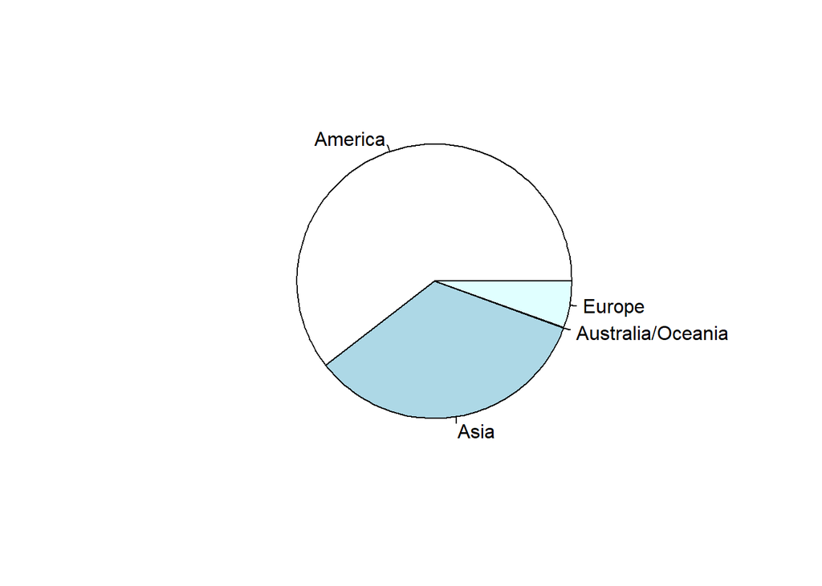

```r
graphics::pie(xtabs(~ continent, starbucks))
```

Based on the pie chart above, we can see clearly that most location of Starbucks outlets can be found in America, with Asia & Europe following behind.

### Asia - The Potential Market of Starbucks Coffee

```r
asia <- subset(starbucks, continent == "Asia")
str(asia)
```

```
## 'data.frame':    9585 obs. of  14 variables:
##  $ X                     : int  0 1 2 3 4 5 6 7 8 9 ...
##  $ storeNumber           : chr  "34638-85784" "32141-267986" "15035-155445" "49646-268445" ...
##  $ countryCode           : Factor w/ 49 levels "AE","AR","AT",..: 20 20 20 20 20 20 20 20 20 20 ...
##  $ ownershipTypeCode     : chr  "LS" "LS" "LS" "LS" ...
##  $ latitude              : num  22.3 22.3 22.3 22.3 22.3 ...
##  $ longitude             : num  114 114 114 114 114 ...
##  $ streetAddressLine1    : chr  "Level 2, Plaza Hollywood, Diamond Hill," "Shop No. G3B, Ground Floor, Wong Tai Sin" "Shop No. G01, Ground Floor, Mikiki 638" "九龍九龍城廣場 地下低層LG10舖" ...
##  $ streetAddressLine2    : chr  "Kowloon" "Shopping Centre, Wong Tai Sin, Kowloon" "Prince Edward Road East," "" ...
##  $ streetAddressLine3    : chr  "" "" "" "" ...
##  $ city                  : Factor w/ 5457 levels ", Klongluang, Pathumthani",..: 2057 2057 2471 5457 2057 2473 2471 2057 2472 2057 ...
##  $ countrySubdivisionCode: Factor w/ 268 levels "00","01","02",..: 66 66 66 66 66 66 66 66 66 66 ...
##  $ countryName           : Factor w/ 49 levels "Argentina","Aruba",..: 18 18 18 18 18 18 18 18 18 18 ...
##  $ sub_continent         : Factor w/ 16 levels "Central America",..: 3 3 3 3 3 3 3 3 3 3 ...
##  $ continent             : Factor w/ 4 levels "America","Asia",..: 2 2 2 2 2 2 2 2 2 2 ...
```

```r
summary(asia)
```

```
##        X         storeNumber         countryCode   ownershipTypeCode
##  Min.   :    0   Length:9585        CN     :2665   Length:9585
##  1st Qu.:17895   Class :character   JP     :1665   Class :character
##  Median :21019   Mode  :character   KR     :1493   Mode  :character
##  Mean   :20110                      TW     : 507
##  3rd Qu.:23537                      TR     : 474
##  Max.   :28246                      ID     : 422
##                                     (Other):2359
##     latitude        longitude      streetAddressLine1 streetAddressLine2
##  Min.   :-8.801   Min.   : 26.77   Length:9585        Length:9585
##  1st Qu.:23.031   1st Qu.:104.12   Class :character   Class :character
##  Median :31.212   Median :120.46   Mode  :character   Mode  :character
##  Mean   :27.825   Mean   :109.75
##  3rd Qu.:35.958   3rd Qu.:127.06
##  Max.   :55.881   Max.   :142.41
##
##  streetAddressLine3       city      countrySubdivisionCode      countryName
##  Length:9585        上海市  : 496   11     : 864           China      :2665
##  Class :character   Seoul   : 385   44     : 561           Japan      :1665
##  Mode  :character   Istanbul: 224   31     : 544           South Korea:1493
##                     深圳市  : 203   41     : 471           Taiwan     : 507
##                     北京市  : 195   13     : 438           Turkey     : 474
##                     (Other) :8081   33     : 428           Indonesia  : 422
##                     NA's    :   1   (Other):6279           (Other)    :2359
##                         sub_continent              continent
##  East Asia                     :6523   America          :   0
##  Southeast Asia                :1674   Asia             :9585
##  Middle East                   :1254   Australia/Oceania:   0
##  Eastern Europe & Northern Asia:  88   Europe           :   0
##  Western Asia                  :  46
##  Central America               :   0
##  (Other)                       :   0
```

Asia is the potential market of Starbucks coffee can be said as the heaven of coffees.

```r
starbucks.sub.asia <- as.data.frame(sort(table(droplevels(asia$sub_continent)),decreasing = T))
names(starbucks.sub.asia)[1]<-paste("sub_continent")
starbucks.sub.asia
```

```
##                    sub_continent Freq
## 1                      East Asia 6523
## 2                 Southeast Asia 1674
## 3                    Middle East 1254
## 4 Eastern Europe & Northern Asia   88
## 5                   Western Asia   46
```

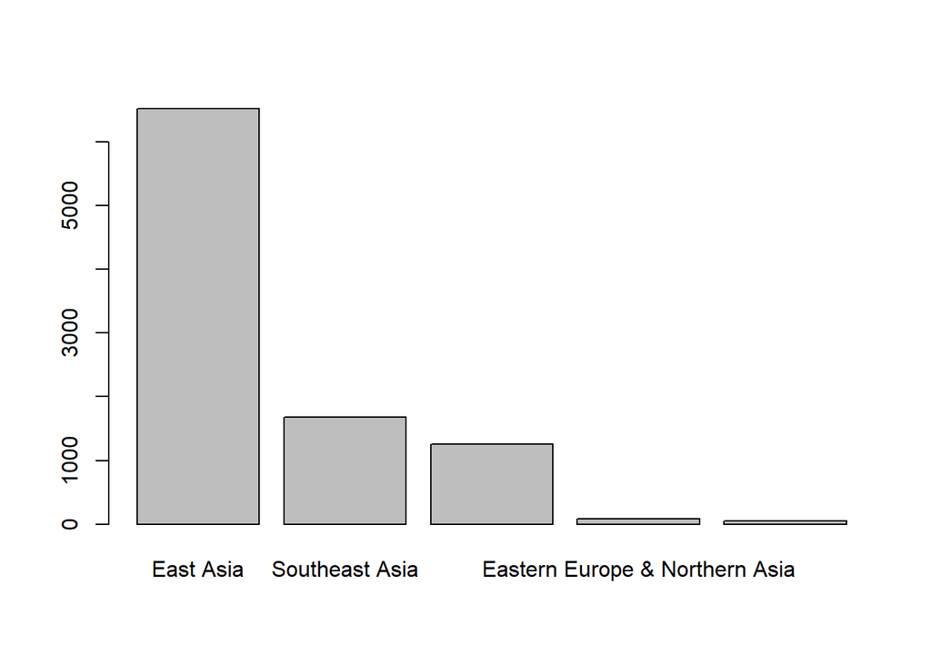

```r
graphics::barplot(xtabs(Freq ~ sub_continent, starbucks.sub.asia))
```

```r
starbucks.asia <- as.data.frame(sort(table(droplevels(asia$countryName)),decreasing = T))
names(starbucks.asia)[1]<-paste("countryName")
starbucks.asia
```

```
##             countryName Freq
## 1                 China 2665
## 2                 Japan 1665
## 3           South Korea 1493
## 4                Taiwan  507
## 5                Turkey  474
## 6             Indonesia  422
## 7           Philippines  396
## 8              Thailand  388
## 9              Malaysia  317
## 10         Saudi Arabia  250
## 11 United Arab Emirates  220
## 12               Kuwait  181
## 13  Hong Kong SAR China  173
## 14            Singapore  150
## 15               Russia   88
## 16                Qatar   46
## 17              Lebanon   43
## 18              Bahrain   39
## 19               Jordan   30
## 20      Macao SAR China   20
## 21                 Oman   17
## 22               Brunei    1
```

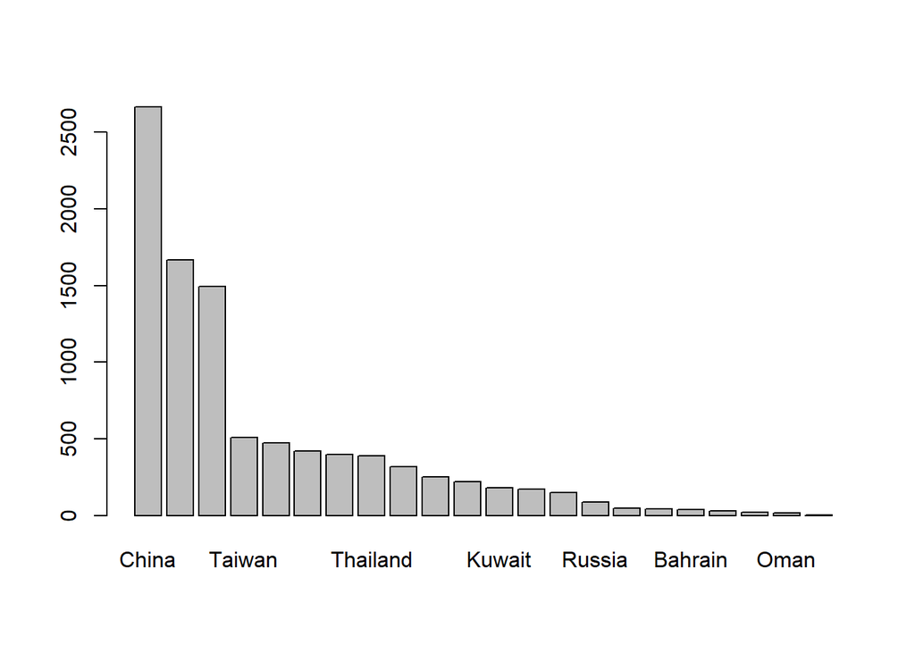

```r
graphics::barplot(xtabs(Freq ~ countryName, starbucks.asia))
```

### What About Starbucks Coffee Outlets in Indonesia?

Starbucks Coffee Indonesia firstly opened its store in Plaza Indonesia, 17 May 2002. Nowadays, Starbucks coffee become the top 10 brand in Indonesia, which is significant part of Indonesian people to experience drink premium coffee in a daily life.

```r
ina <- subset(starbucks, countryName == "Indonesia")
ina <- ina[,-c(5,6,14,15,16,17)]
names(ina)
```

```
##  [1] "X"                      "storeNumber"            "countryCode"
##  [4] "ownershipTypeCode"      "streetAddressLine1"     "streetAddressLine2"
##  [7] "streetAddressLine3"     "city"                   "countrySubdivisionCode"
## [10] "countryName"            "sub_continent"
```

```r
str(ina)
```

```
## 'data.frame':    422 obs. of  11 variables:
##  $ X                     : int  17117 17118 17119 17120 17121 17122 17123 17124 17125 17126 ...
##  $ storeNumber           : chr  "1808-137814" "53766-286006" "52005-280485" "58345-292512" ...
##  $ countryCode           : Factor w/ 49 levels "AE","AR","AT",..: 22 22 22 22 22 22 22 22 22 22 ...
##  $ ownershipTypeCode     : chr  "LS" "LS" "LS" "LS" ...
##  $ streetAddressLine1    : chr  "JL. Tol Jagorawi KM 10.6" "Jalan Alternatif Cibubur No. 12A" "Jalan Pendidikan No. 1 RT 1 RW 4" "Jatimelati Pondok Melati" ...
##  $ streetAddressLine2    : chr  "1st Fl Zona B B1-1" "" "Cijantung Pasar Rebo" "" ...
##  $ streetAddressLine3    : chr  "" "" "" "" ...
##  $ city                  : Factor w/ 5457 levels ", Klongluang, Pathumthani",..: 2223 1159 2223 360 2223 1159 2227 2223 1186 1159 ...
##  $ countrySubdivisionCode: Factor w/ 268 levels "00","01","02",..: 145 143 145 143 148 143 145 148 148 148 ...
##  $ countryName           : Factor w/ 49 levels "Argentina","Aruba",..: 20 20 20 20 20 20 20 20 20 20 ...
##  $ sub_continent         : Factor w/ 16 levels "Central America",..: 12 12 12 12 12 12 12 12 12 12 ...
```

```r
summary(ina)
```

```
##        X         storeNumber         countryCode  ownershipTypeCode
##  Min.   :17117   Length:422         ID     :422   Length:422
##  1st Qu.:19088   Class :character   AE     :  0   Class :character
##  Median :20302   Mode  :character   AR     :  0   Mode  :character
##  Mean   :22360                      AT     :  0
##  3rd Qu.:28053                      AW     :  0
##  Max.   :28158                      BE     :  0
##                                     (Other):  0
##  streetAddressLine1 streetAddressLine2 streetAddressLine3        city
##  Length:422         Length:422         Length:422         Jakarta  :185
##  Class :character   Class :character   Class :character   Surabaya : 32
##  Mode  :character   Mode  :character   Mode  :character   Tangerang: 29
##                                                           Bandung  : 21
##                                                           Bekasi   : 21
##                                                           Bogor    : 16
##                                                           (Other)  :118
##  countrySubdivisionCode    countryName                         sub_continent
##  JK     :138            Indonesia:422   Southeast Asia                :422
##  JW     :103            Argentina:  0   Central America               :  0
##  JB     : 56            Aruba    :  0   Central Europe                :  0
##  JI     : 32            Austria  :  0   East Asia                     :  0
##  BT     : 25            Bahamas  :  0   Eastern Europe & Northern Asia:  0
##  BA     : 20            Bahrain  :  0   Middle East                   :  0
##  (Other): 48            (Other)  :  0   (Other)                       :  0
```

```r
nrow(ina)
```

```
## [1] 422
```

```r
starbucks.ina <- as.data.frame(sort(table(droplevels(ina$city)),decreasing = T))
names(starbucks.ina)[1]<-paste("city")
starbucks.ina
```

```
##                    city Freq
## 1               Jakarta  185
## 2              Surabaya   32
## 3             Tangerang   29
## 4               Bandung   21
## 5                Bekasi   21
## 6                 Bogor   16
## 7                 Medan   15
## 8              Semarang   13
## 9              Denpasar   12
## 10                Depok    9
## 11                 Bali    7
## 12               Badung    6
## 13        Jakarta Utara    4
## 14             Karawang    4
```

[output cut: 30 more lines]

At least, there are 422 outlets of Starbucks Coffee which you can find in Indonesia, which most of them are availables in Jakarta, and Surabaya, Tangerang, Bandung, Bekasi, Bogor following behind.

We can say that Starbucks in Indonesia has spread almost across the province, from East to West of Indonesia.

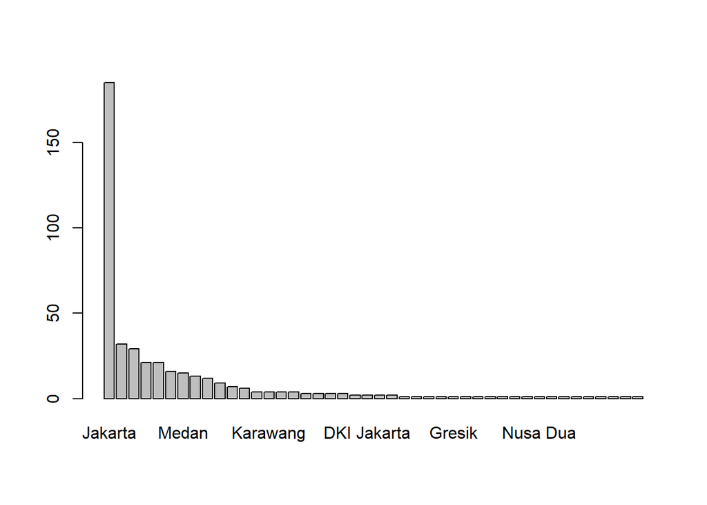

```r
graphics::barplot(xtabs(Freq ~ city, starbucks.ina))
```

### Conclusion

Now, what do I know about Starbucks Coffee?

I know that it first store was opened in Seattle’s historic Pike Place Market in 1971, and it was growth as the coffeehouse by Howard Schultz’s help.

Asia is the next potential market after its origin place America. East Asia and Southeast Asia are the top 2 of most Starbucks outlets can found in Asia.

### Reference

1. https://www.kaggle.com/datasets/starbucks/store-locations
2. https://www.kaggle.com/code/juniorbueno/starbucks-maps-location
3. https://www.starbucks.com/about-us/
4. https://www.beritasatu.com/archive/74352/starbucks-raih-peringkat-top-10-brand-di-indonesia
5. https://www.starbucks.co.id/about-us/our-heritage/starbucks-in-indonesia